# Simple Parametrization

- No review
- No metareview
- No harm from kludges
- New Developments Rate: 1

Pure Strategiess:

- Developer 1: Dev: Kludgy/Rev: Careful (does not matter)/Meta: Accurate (does not matter)
- Developer 2: Dev: Diligent/Rev: Careful (does not matter)/Meta: Accurate (does not matter)
- Developer 3: Dev: Diligent/Rev: Careful (does not matter)/Meta: Accurate (does not matter)

## 500 simulation steps

Estimated time for 30 repetitions of $8^3$ combinations: 12 min per parametrization, 25h (125 parametrizations)

### 30 repetitions

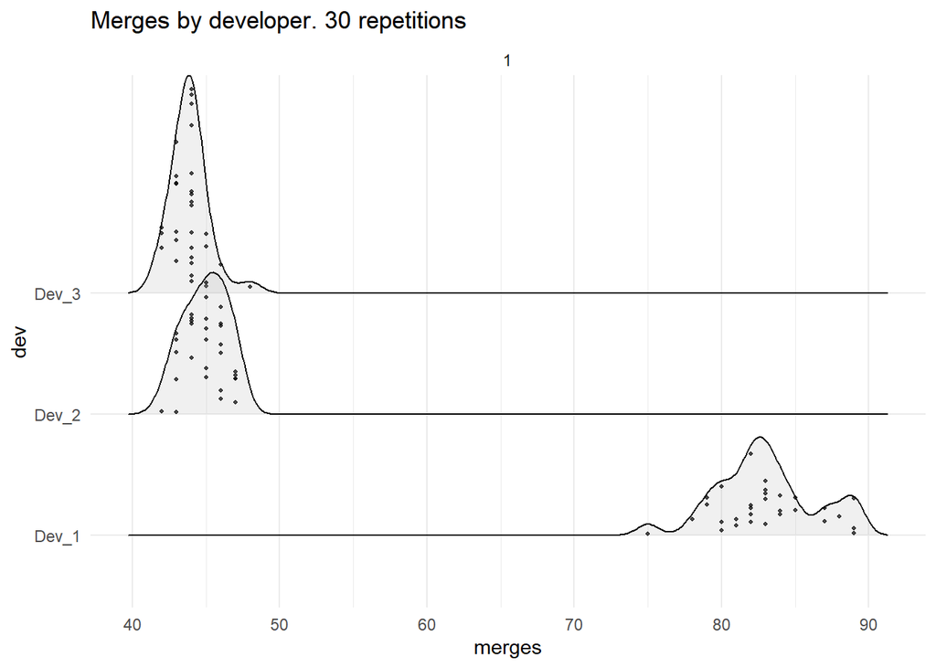

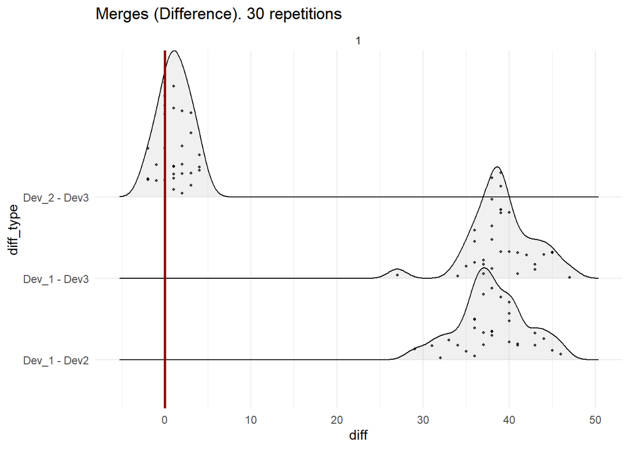

### Samples of 20 repetitions

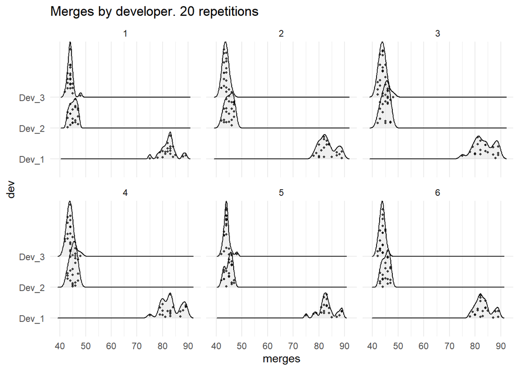

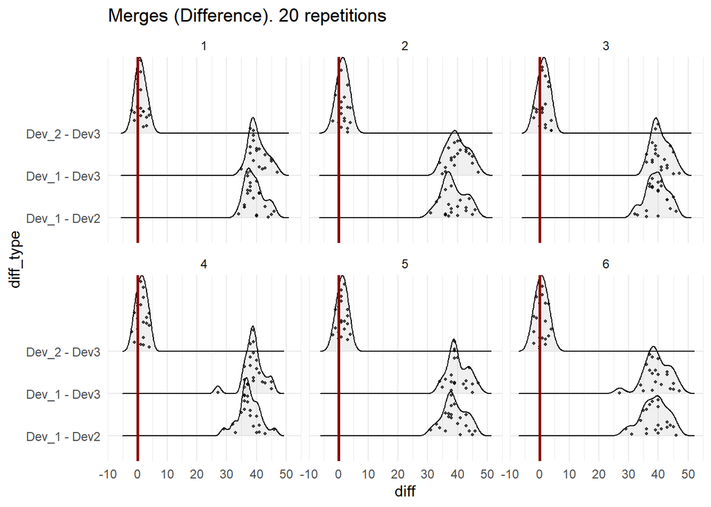

### Samples of 10 repetitions

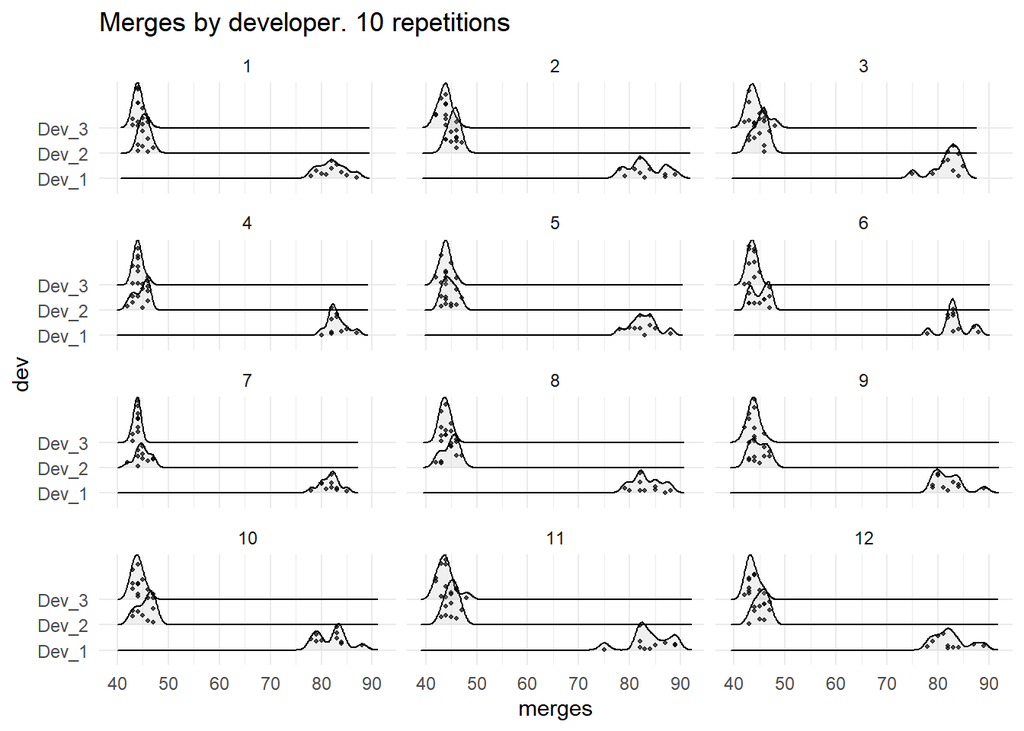

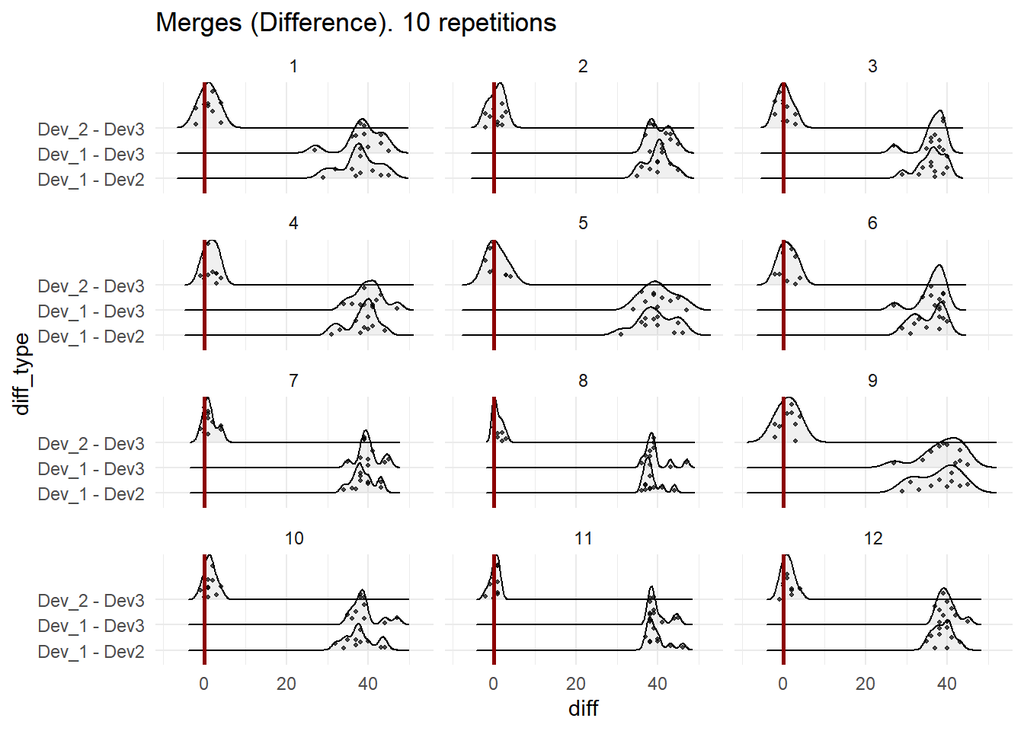

## 300 simulation steps

Estimated time for 30 repetitions of $8^3$ combinations: 8.5 min per parametrization, 18h (125 parametrizations)

### 30 repetitions

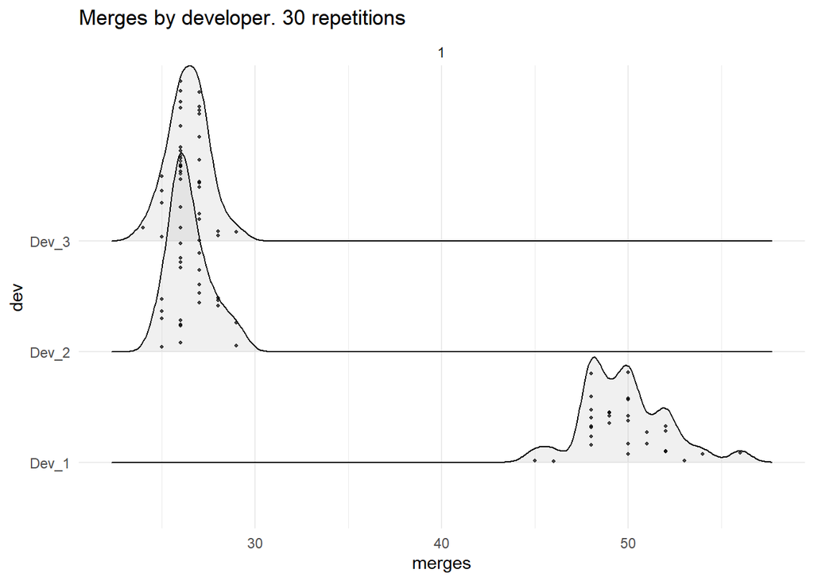

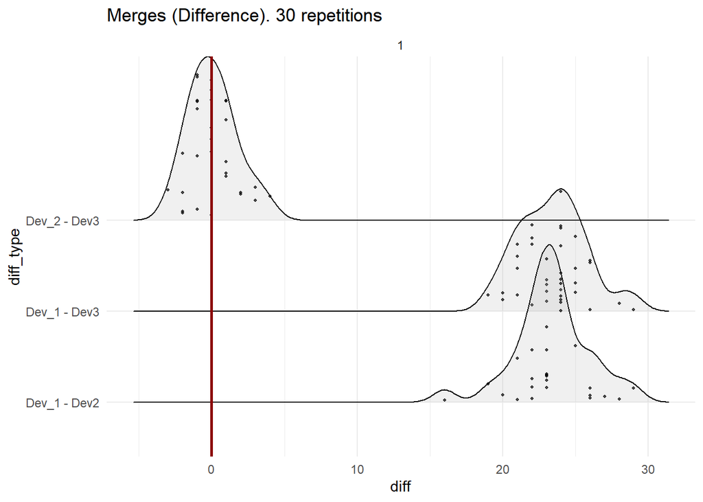

### Samples of 20 repetitions

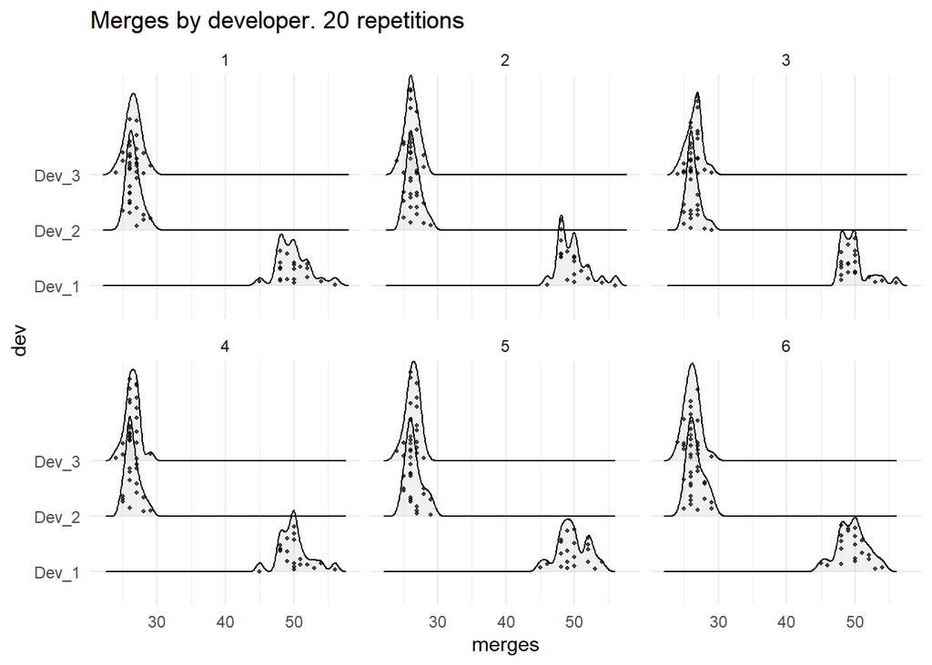

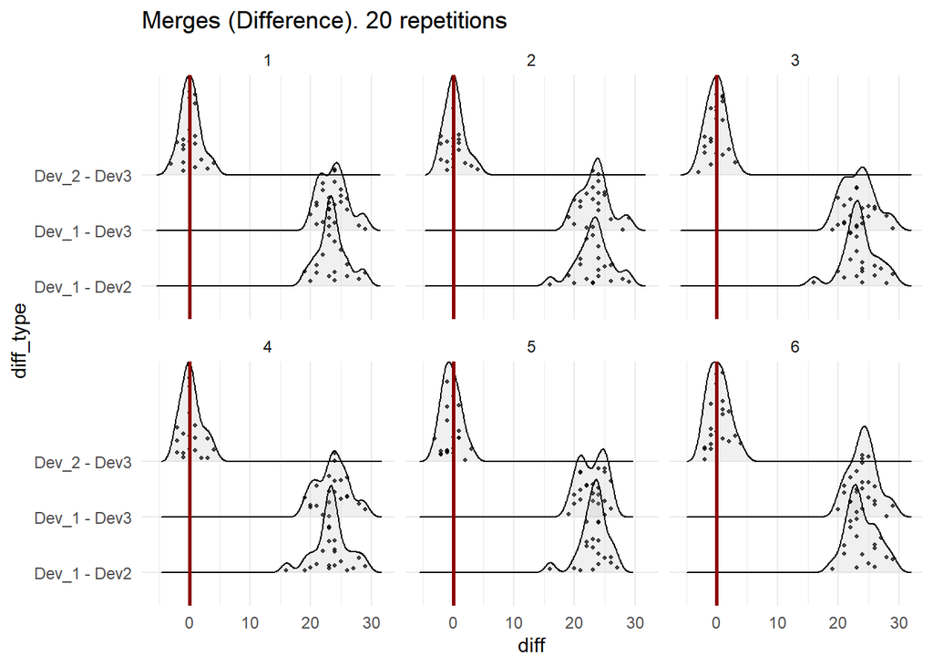

### Samples of 10 repetitions

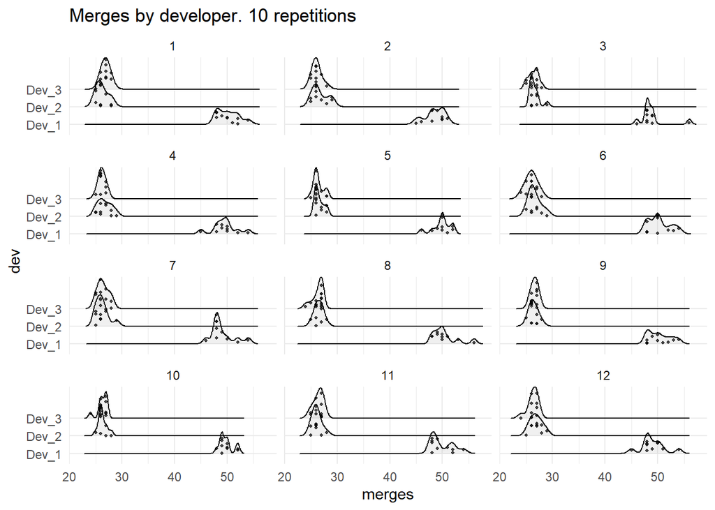

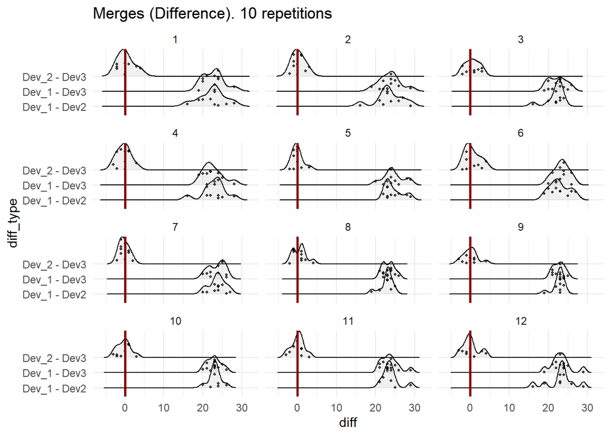

## 100 simulation steps

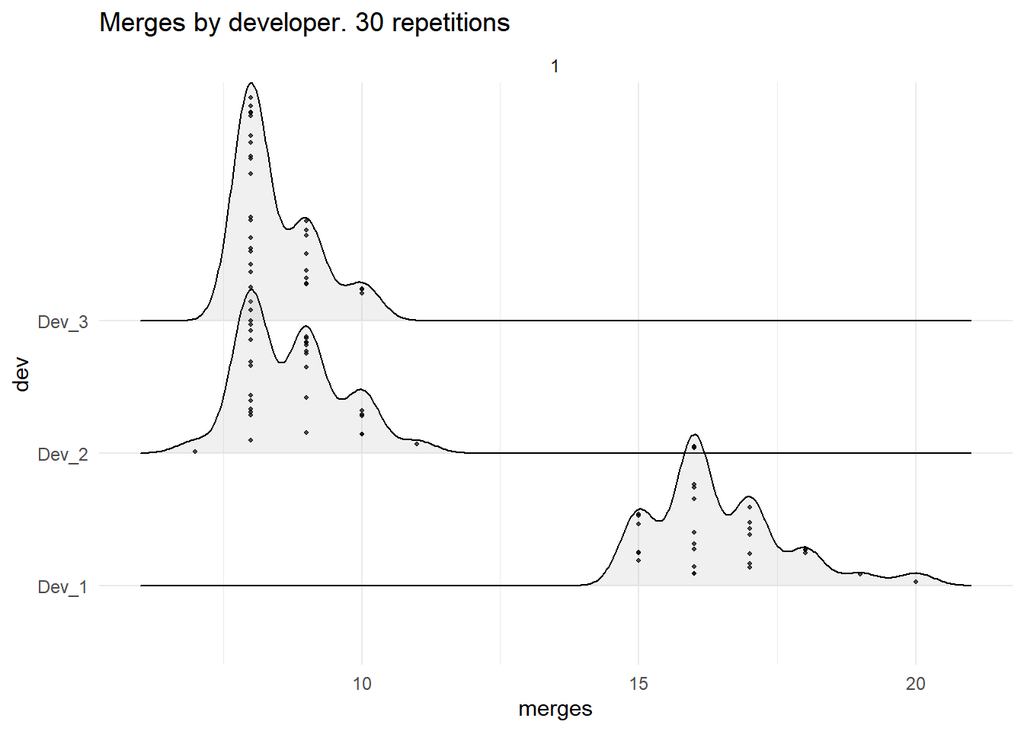

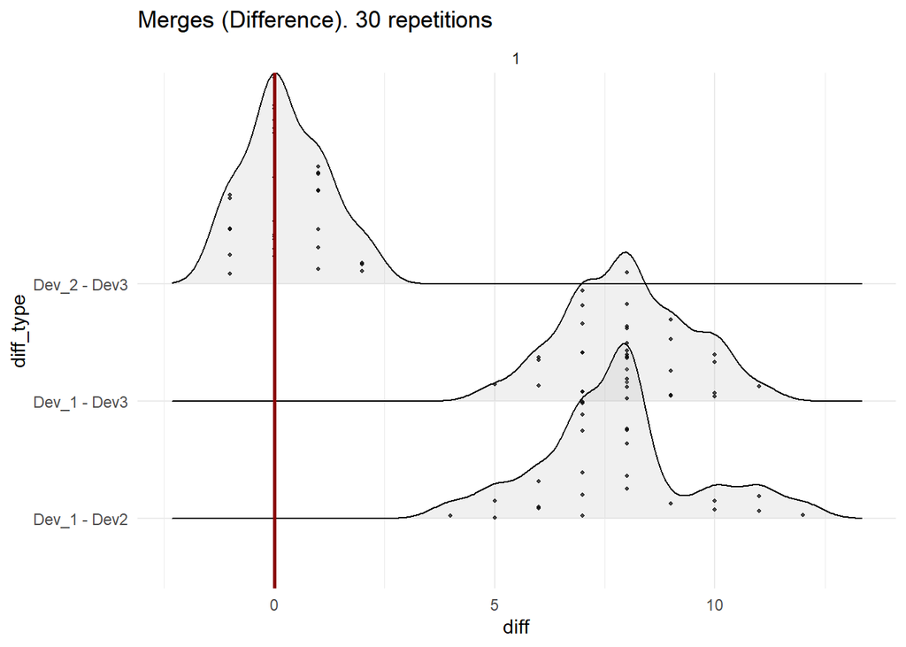

### Samples of 20 repetitions

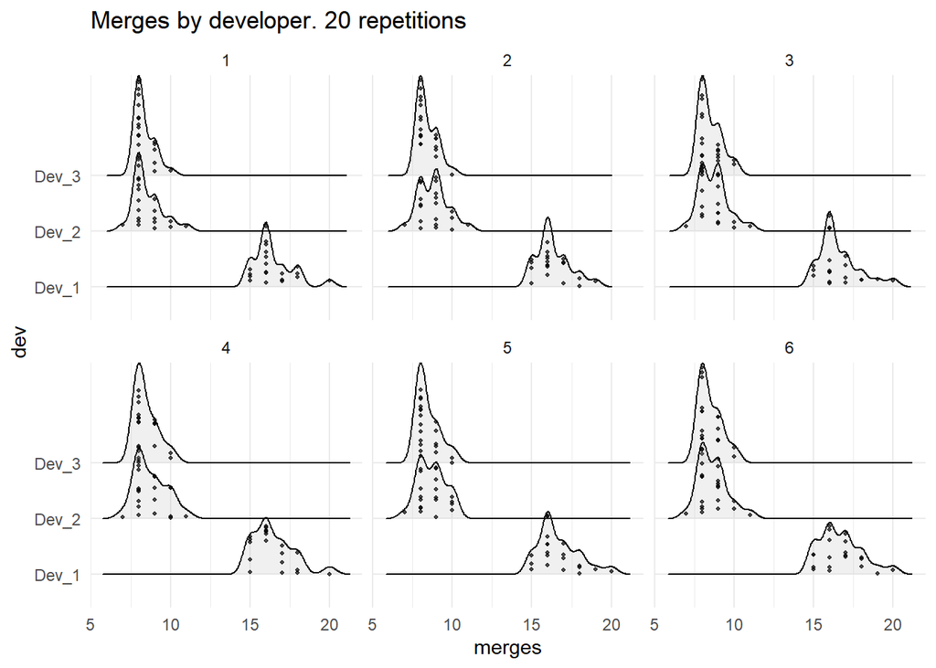

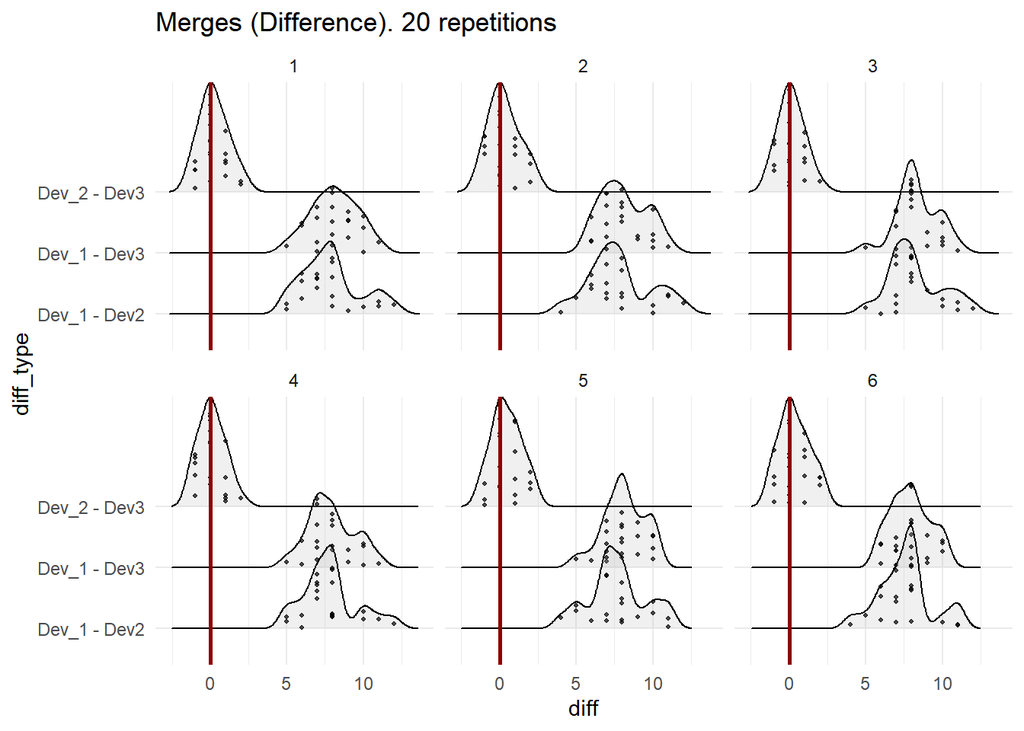

### Samples of 10 repetitions

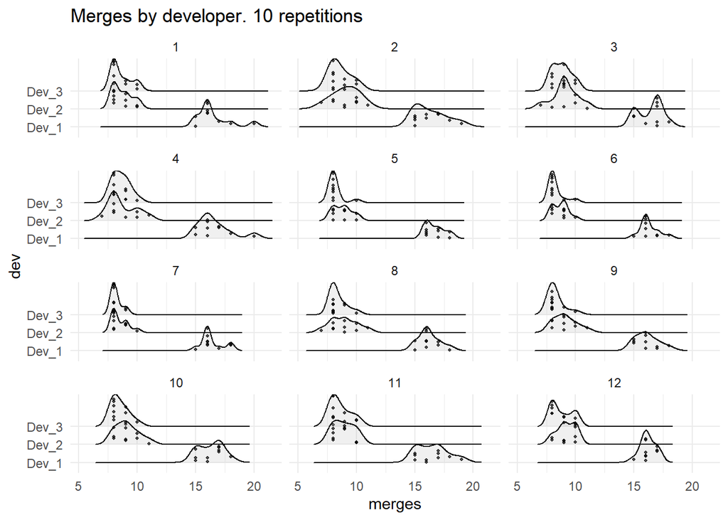

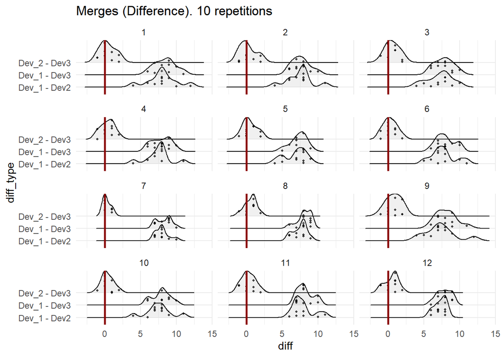

# Complex Parametrization

- 100% review
- 100% metareview
- No harm from kludges
- New Developments Rate: 1

Pure Strategiess:

- Developer 1: Dev: Kludgy/Rev: Careful/Meta: Accurate
- Developer 2: Dev: Diligent/Rev: Negligent/Meta: Accurate
- Developer 3: Dev: Diligent/Rev: Careful/Meta: Inaccurate

## 500 simulation steps

Estimated time for 30 repetitions of $8^3$ combinations: 15 min per parametrization, 31h (125 parametrizations)

### 30 repetitions

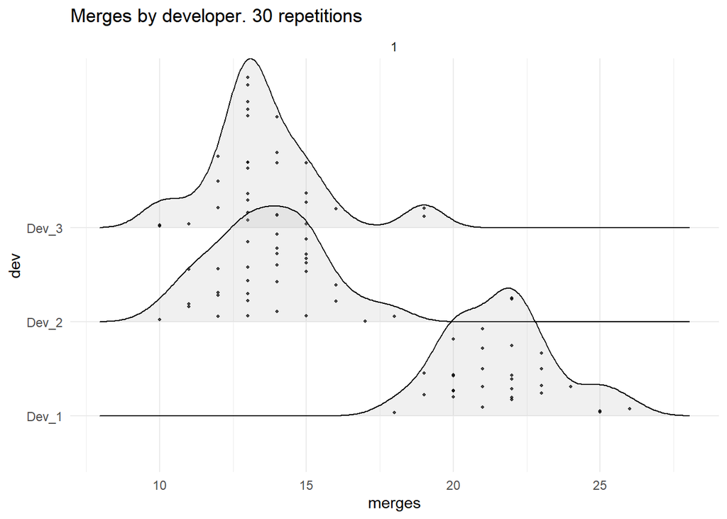

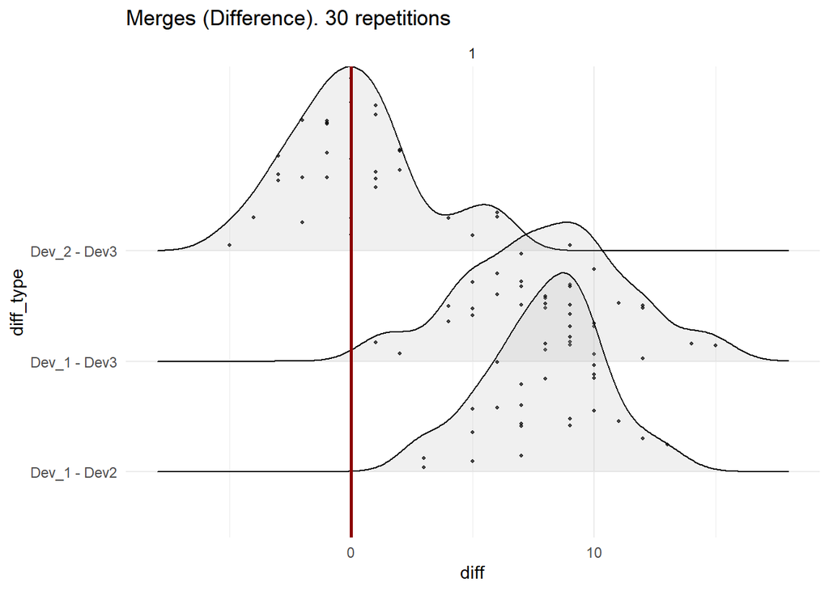

### Samples of 20 repetitions

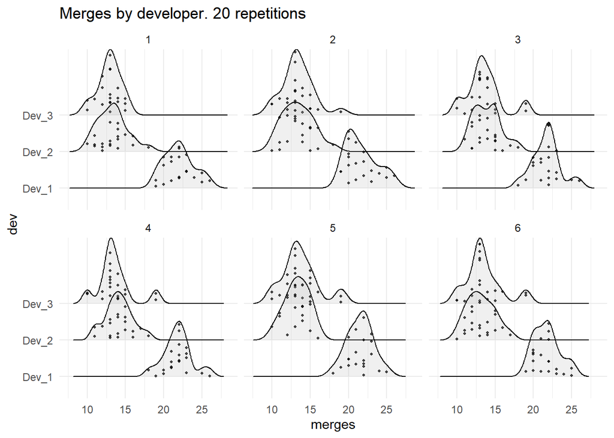

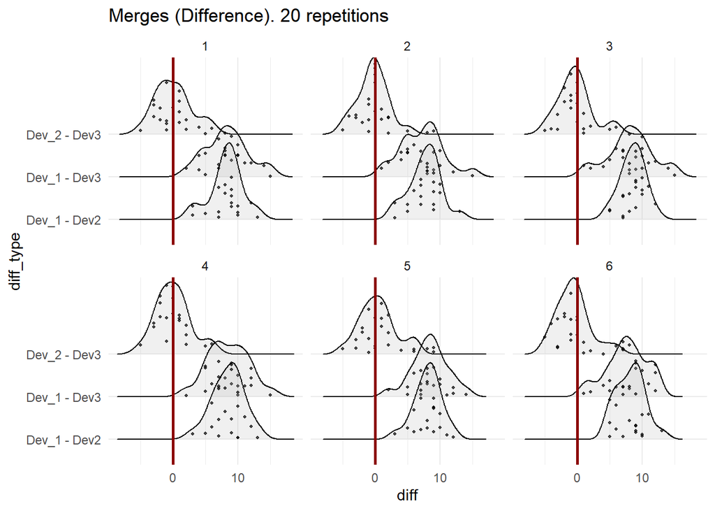

### Samples of 10 repetitions

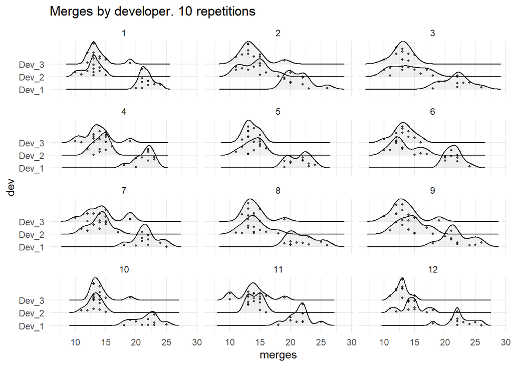

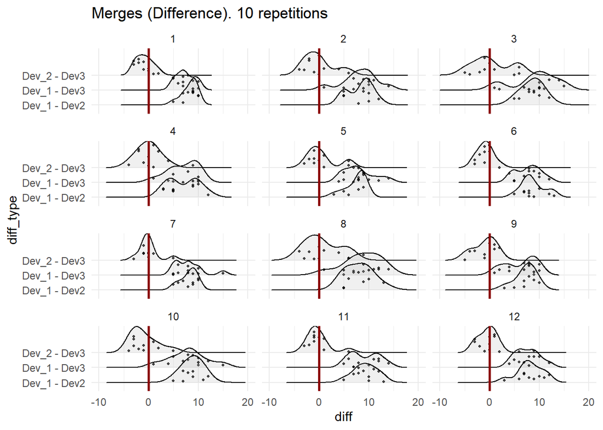

Estimated time for 30 repetitions of $8^3$ combinations: 16 min per parametrization, 33.5h (125 parametrizations)

### 30 repetitions

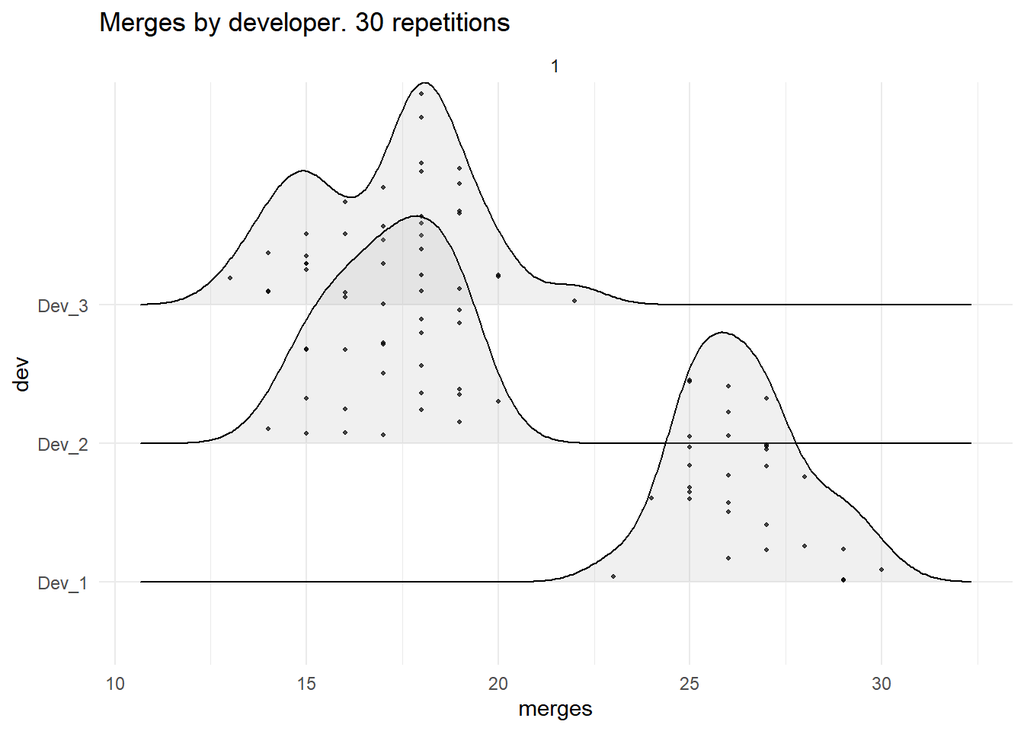

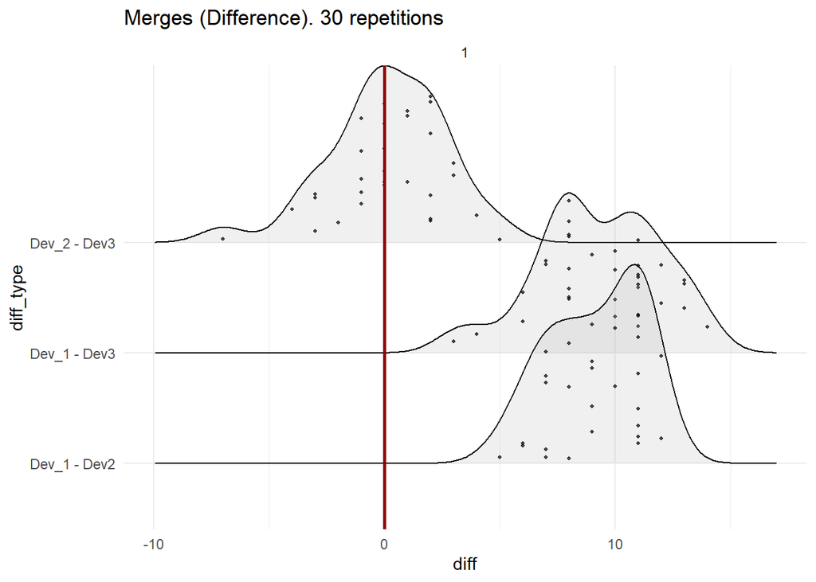

### Samples of 20 repetitions

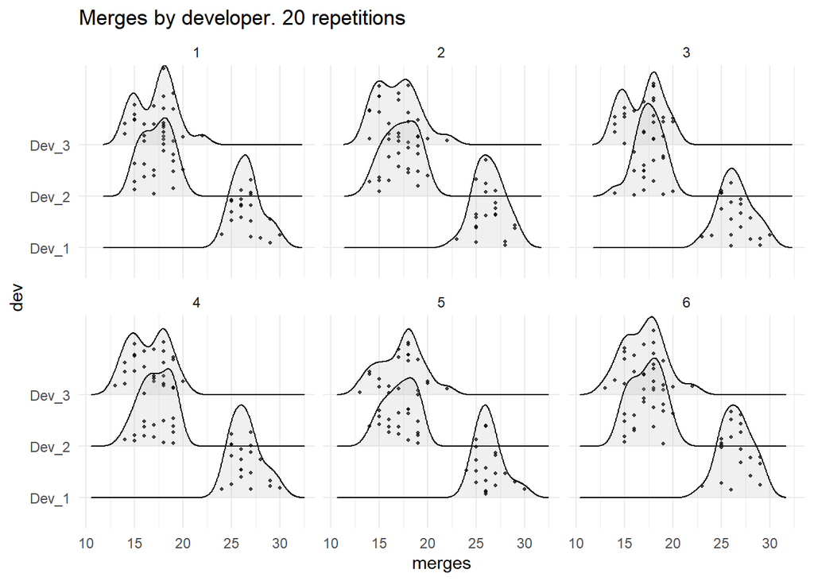

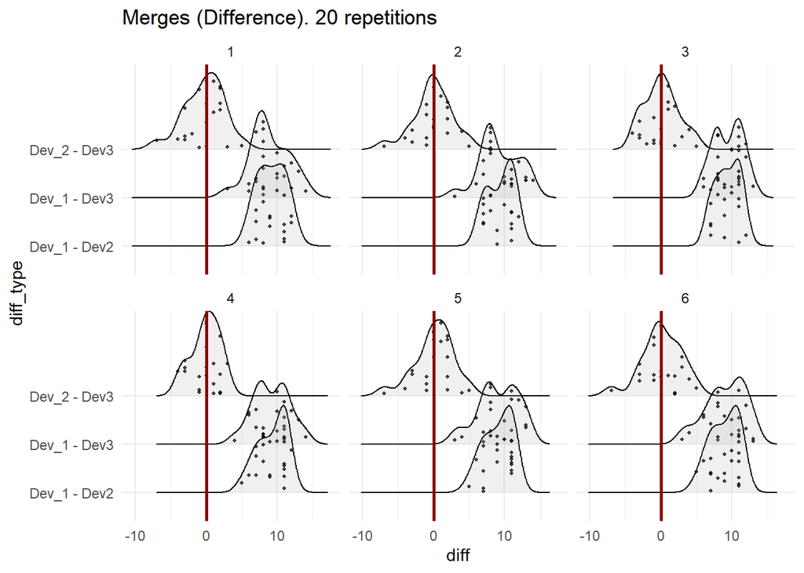

### Samples of 10 repetitions

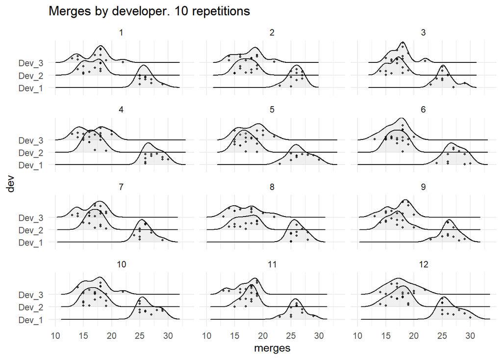

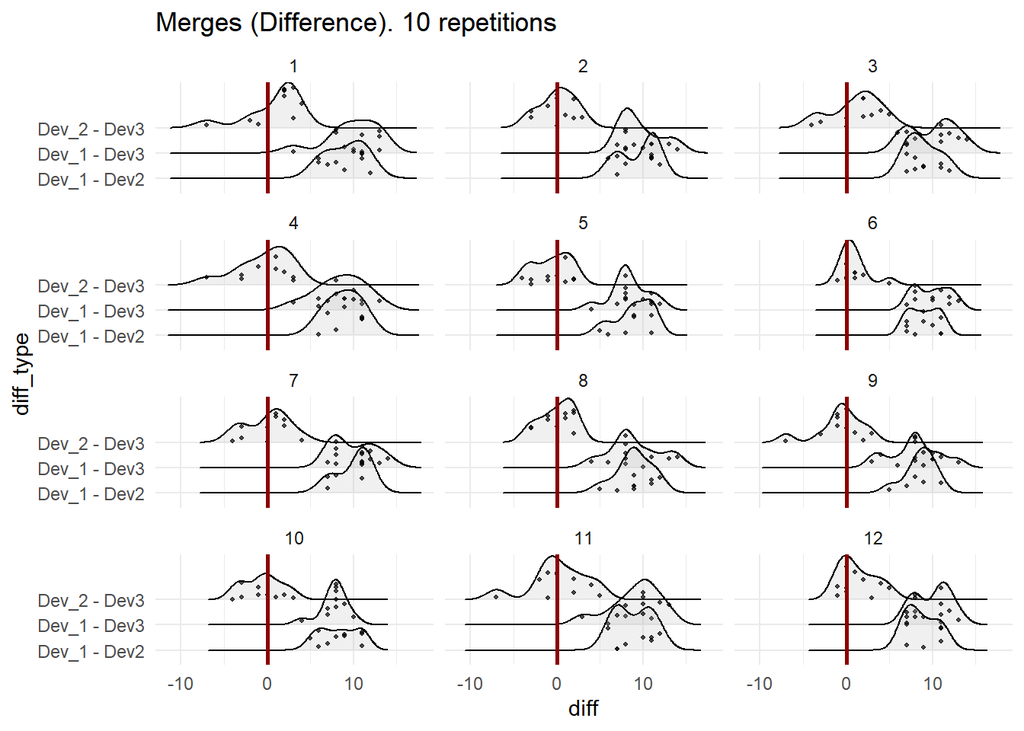